# Lab 1 Notes

Kyle N. Payne  
1/19/2016

### Getting Started

- Welcome!
- Lab Time : Wed 12-1:50pm
- Course Website : compass2g.illinois.edu
- TA Website : kylenpayne.github.io
- TA Name : Kyle N. Payne, (Kyle, K-Pax, “Hey…man”)
- TA Office Hours : Wed 10-11:00pm
- TA Email : knpayne2@illinois.edu

### Book

- Title : An Introduction to Statistical Methods and Data Analysis
- Author(s) : R Lyman Ott, Michael Longnecker
- Edition : 6th
- Can be found on most retailers like Amazon.com, abebooks.com, etc…
- Also can be found by google-ing Title + 'pdf'

### Software

- Software is a huge component of statistical analysis
- We will support SAS and R usage for this course
- SAS is a suite of tools for statistical analysis
- R is a programming language primarily for statistical analysis

### SAS

- SAS inc. is the worlds largest privately held software company.
- Used by most fortune 500 companies http://archive.fortune.com/2010/01/21/technology/sas_best_companies.fortune/index.htm
- SAS Software has over 200 components
- Can perform many statistical analyses with limited effort
- Presents a robust suite of industry standard tools. https://en.wikipedia.org/wiki/SAS_(software)#cite_note-encycl-2

### R

- “Much closer to the metal” than SAS
- Can be used to create your own functions, libraries, etc…
- Requires more effort
- But this results in arguably better skill development

### Accessing SAS

- N120
- Many campus computer labs
- Remotely through ACES
- SAS OnDemand

### Accessing R

- Rstudio : https://www.rstudio.com/
- On many workstation on campus
- Can be downloaded on most computers
- Very lightweight software

### Pragmatics

- When you turn in homework, please show all work. This amounts to:
- All the steps in a math problem
- All of the code you used to solve a problem
- All graphs, figures, tables, etc.

Without these, you are banking on your result being 100% correct.

### Some Theory

- Random Variable : A variable whose value is subject to variations due to chance
- Population : A population is a complete set of items that share at least one property in common.
- Parameter : A characteristic of the population.
- Statistic : A quantity calculated from a sample.
- Estimator : A statistic that estimates a parameter. e.g. \( \bar{X} = \sum_{i=1}^{n}X_{i} \Rightarrow \mu \)

### Some Theory

- In inferential statistics, we typically attempt to do two things.
- Estimate the value of a population parameter using sample statistics.
- Establish if the population value is greater than/less than/equal to a value given our estimate. (That is the statistical test alex mentioned briefly).

### Some Theory

- In class, Dr. Lipka mentioned cumulative frequency and class intervals.
- Let's go ahead and define these:
- Class interval. Take X to be some random variable (let's say height of US men). Let's assume we take a random sample of men from the US, and measure their heights. We are taking \( n \) measurements. (e.g. \( n=1,2,3, ... \) ). Then let \( X_{i} \) denote the ith sample measurement of height. Let's then sort these values from smallest to largest. Let's denote these data \( X_{(i)} \), where \[ X_{(1)} < X_{(2)} < ... < X_{(n)} \].

### Some Theory

- Then \( X_{(1)} \) is the minimum value of the sample
- And \( X_{(n)} \) is the maximum value of the sample.

We call the \( X_{(i)} \)'s order statistics (because we ordered them, get it?).

Assume we are going to break these order statistics into \( k \) intervals, and count the number of observations in them, then we can define \( I_{1}, I_{2}, ..., I_{k} \), to be these intervals, where typically the first intervals starts at \( X_{(1)} \), and the last interval ends at \( X_{(n)} \).

### Some Theory

- The cumulative frequency is the sum of these bins up to some amount.
- Let's denote the count of samples in the \( i^{th} \) interval as \( C(I_{i}) \)
- Let's denote the frequency of the \( k^{th} \) interval as \[ f_{k} = \frac{C(I_{k})}{n} \]
- Then the cumulative frequency is up to some number \( y \) is the sum of these frequencies up to the bin that contains \( y \).

### Example

Let's try an example, but first we need to know some CS concepts.

### About all of the CS you need to know in one slide

- Objects are models of information
- In R we use objects to store and manipulate information
- This information can be data, models, statistics, numbers, names, …
- We manipulate these objects with functions.
- We assign information to objects with the '<-' symbol

### Example

```r
data <- read.csv("~/Desktop/CSPC 440 TA/darwin.dat", sep="")
colnames(data)
```

```
[1] "id"    "yield" "width"
```

### Example

```r
data
```

```
   id yield width
1   1  23.5  17.4
2   2  12.0  20.4
3   3  21.0  20.0
4   4  22.0  20.0
5   5  19.1  18.4
6   6  21.5  18.6
7   7  22.1  18.6
8   8  20.4  15.3
9   9  18.3  16.5
10 10  21.6  18.0
11 11  23.3  16.3
12 12  21.0  18.0
13 13  22.1  12.8
14 14  23.0  15.5
15 15  12.0  18.0
```

### Example

```r
yield <- data$yield
breaks <- seq(min(yield), max(yield), length.out=5)
yield_cut <- cut(yield, breaks, right=F)
yield_freq <- table(yield_cut)
cum_freq <- cumsum(yield_freq)
yield_freq
```

```
yield_cut
  [12,14.9) [14.9,17.8) [17.8,20.6) [20.6,23.5)
          2           0           3           9
```

```r
cum_freq
```

```
  [12,14.9) [14.9,17.8) [17.8,20.6) [20.6,23.5)
          2           2           5          14
```

### Objects

These are both objects

```r
typeof(data$yield)
```

```
[1] "double"
```

```r
yield <- data$yield
typeof(yield)
```

```
[1] "double"
```

### Functions

Functions hold the same interpretation as they do in mathematics

- \( x \rightarrow f(x) \)

```r
mean
```

```
function (x, ...)
UseMethod("mean")
<bytecode: 0x7fecfdabed50>
<environment: namespace:base>
```

```r
hist
```

```
function (x, ...)
UseMethod("hist")
<bytecode: 0x7fecfba672a0>
<environment: namespace:graphics>
```

### Functions

Functions act on objects, and return other objects. These can be numbers, data, or even plots.

```r
mean(yield)
```

```
[1] 20.19333
```

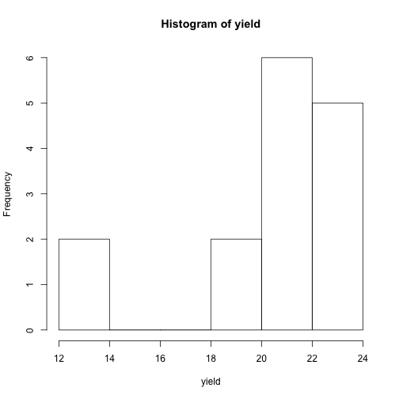

```r
hist(yield)
```

### SAS

Much of this is not applicable to SAS.

In SAS you type some commands and it essentially flings tons of information at you.